# Loss Functions

## In context...

"Loss" refers to a measure of the error or discrepancy between the predicted output of a machine learning model and the actual or desired output.

Common loss functions for different machine learning tasks:

- Mean Squared error, used in regression problems
- Binary Cross-Entropy, used in classification
- Categorical Cross-Entropy, used in multi-class classification problems

## What Loss Function does ChatGPT use?

ChatGPT uses maximum likelihood estimation (MLE) as an objective function, rather than a specific loss function.

During training, the model is trained to predict the next word in a sequence given the previous words. The goal is to maximize the likelihood of generating the correct next word.

#### The negative log-likelihood loss function, often referred to as cross-entropy loss:

**NLL = -log(P(true next word | previous words))**

This loss function penalizes the model more when it assigns low probabilities to the correct next word, encouraging it to learn to generate more accurate and coherent responses.

## Visualizing our loss in the small-scale ChatGPT model!

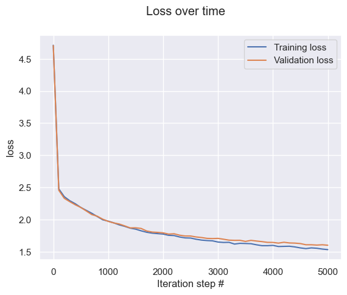

Over time, the 'loss' that we calculate each iteration is stored and used to create a loss gradient which is used to continuously update the parameters that we feed into the model.

## How is this implemented in our model?

Over time, the 'loss' that we calculate each iteration is stored and used to create a loss gradient which is used to continuously update the parameters that we feed into the model.

### Example:

```python
import torch
import torch.optim as optim

# Define your model
model = YourModel()

# Define the Adam optimizer
optimizer = optim.Adam(model.parameters(), lr=0.001)

# Perform a single optimization step
optimizer.zero_grad()  # Clear accumulated gradients
loss = compute_loss()  # Compute the loss
loss.backward()  # Backpropagation
optimizer.step()  # Update the model parameters
```